# Modelos forestales

Cristian Gañan

# Modelos

Con los siguientes datos de P. patula, explorar modelos para estimarlo, como los modelos de vB, Schumacher y Chapman-Richards. De acuerdo con los criterios que usted juzgue necesarios, escoja la mejor opción. Trate de buscar usted sus valores de partida con algún razonamiento lógico, o que usted conozca o con modelos que le ofrezca la literatura.

## Von Bertalanffy

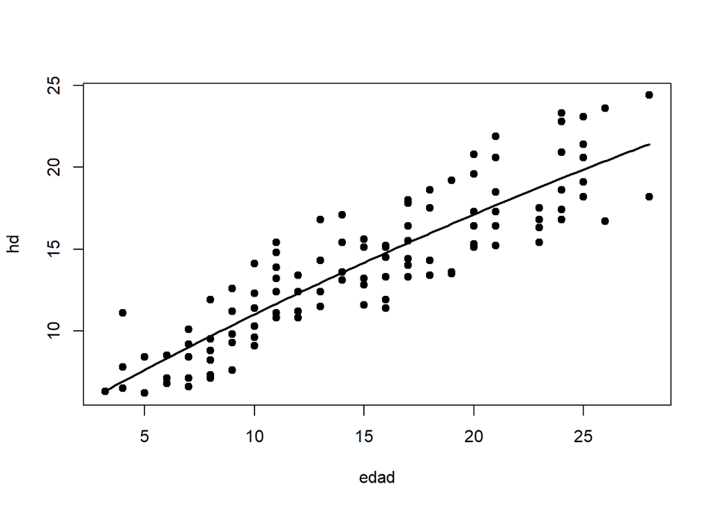

**Figura 1: Modelo VB**

```r
library(tidyverse)
datos<- read.csv2("taller5.csv", dec = ".")
datos<- datos %>% select(-ï..)

library(FSA)
part<- vbStarts(hd ~ edad, data = datos)

modelo<- nls(hd ~ Linf*(1-exp(-K*(edad-t0))), data = datos,
             start = part)


fitPlot(modelo)
```

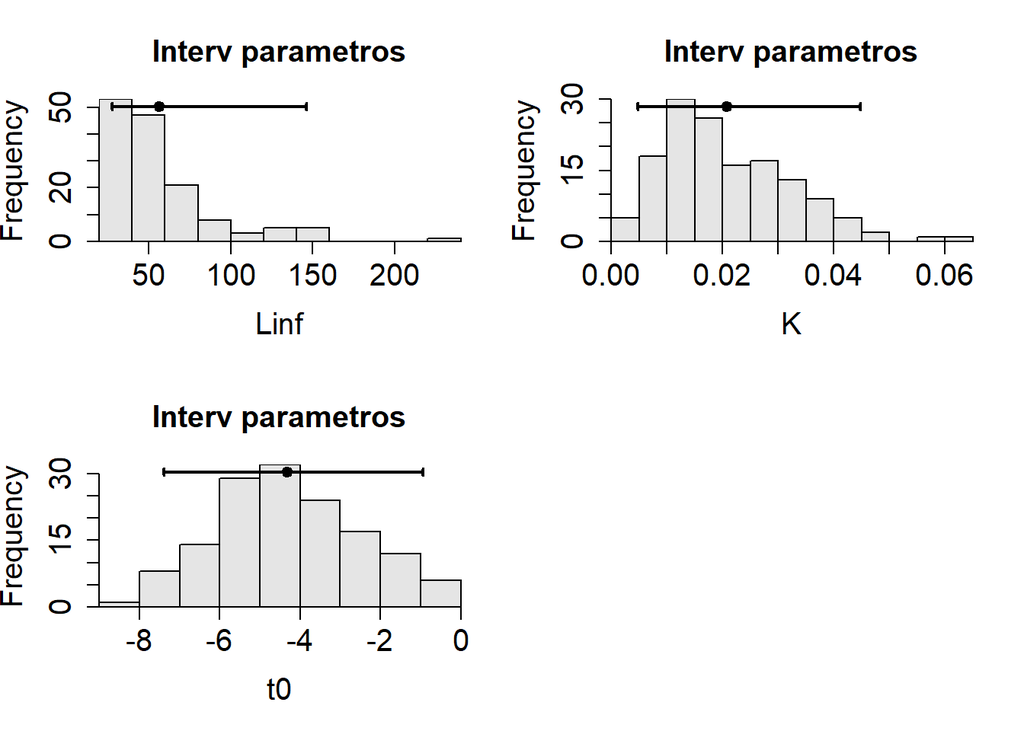

**Figura 1: Modelo VB**

```
##           95% LCI      95% UCI
## Linf 27.576000200 145.83932106
## K     0.004784146   0.04480331
## t0   -7.390284027  -0.94476945
```

```r
library(nlstools)
limp<- nlsBoot(modelo, niter = 200)

confint(limp,plot=TRUE,cex.lab=1.5,cex.axis=1.5,cex.main=1.5,main="Interv parametros")
```

```r
htest(limp,"K",0.24,"less")
```

```
##   Ho Value p value
## K     0.24       0
```

```r
broom::tidy(modelo)
```

| term | estimate | std.error | statistic | p.value |
| --- | --- | --- | --- | --- |
| Linf | 57.15768727 | 49.98799115 | 1.143428 | 0.25551139 |
| K | 0.01419236 | 0.01653293 | 0.858430 | 0.39264833 |
| t0 | -5.07897715 | 2.90764221 | -1.746768 | 0.08365848 |

```r
broom::glance(modelo)
```

| sigma | isConv | finTol | logLik | AIC | BIC | deviance | df.residual |
| --- | --- | --- | --- | --- | --- | --- | --- |
| 2.083647 | TRUE | 1.26286e-07 | -226.7025 | 461.4051 | 472.0588 | 447.1833 | 103 |

**Tabla 1: modelo VB**

En la **figura 1**, se puede observar el ajuste del modelo, al parecer ajusta bien los datos, sin embargo, al observar las distribuciones de los parámetros `Linf`, `K` y $t_0$ solo este último sigue una distribución normal, el `p-value` para `k` es significativo lo que quiere decir que k es una buena estimación como se dio por el modelo.

Ahora se hace preciso, mirar cómo se comporta el modelo si se separa por localidad, para esto, se usa la variable `loc` de los datos.

```r
dato1<- datos %>% group_by(loc) %>%  nest()

modelo<- function(data){
  part<- vbStarts(hd ~ edad, data = data)
  nls(hd ~ Linf*(1-exp(-K*(edad-t0))), data = data,
             start = part)
}

dato1<- dato1 %>%
  mutate(model= map(data, modelo))


model2<- dato1 %>%
  mutate(model2= map(model, broom::tidy)) %>%
  unnest(model2, .drop = TRUE)

model2
```

| loc | term | estimate | std.error | statistic | p.value |
| --- | --- | --- | --- | --- | --- |
| PB | Linf | 85.004374388 | 133.90952681 | 0.6347896 | 0.52782852 |
| PB | K | 0.008218268 | 0.01533025 | 0.5360818 | 0.59376042 |
| PB | t0 | -5.297887876 | 2.93336900 | -1.8060762 | 0.07560887 |
| CA | Linf | 42.877861329 | 18.75120090 | 2.2866728 | 0.02820083 |
| CA | K | 0.026162951 | 0.01834749 | 1.4259692 | 0.16249169 |
| CA | t0 | -3.187752655 | 2.36507808 | -1.3478425 | 0.18613012 |

```r
model3<- dato1 %>%
  mutate(model3= map(model, broom::glance)) %>%
  unnest(model3, .drop = TRUE)

model3
```

| loc | sigma | isConv | finTol | logLik | AIC | BIC | deviance | df.residual |
| --- | --- | --- | --- | --- | --- | --- | --- | --- |
| PB | 1.513092 | TRUE | 1.491653e-06 | -121.28268 | 250.5654 | 259.3841 | 146.52469 | 64 |
| CA | 1.548275 | TRUE | 7.898111e-06 | -70.82627 | 149.6525 | 156.3068 | 86.29754 | 36 |

**Tabla 2: modelos por localidad**

Haciendo modelos separados por localidad hay un mejor ajuste, muestra de ello es la `devience` más pequeña en ambos modelos por `sitio` que en los datos completos el mismo patrón lo sigue el `AIC` y el `BIC` **Tabla 1** y **Tabla 2**

## Schumacher

El modelo presentado es de la forma $\beta_{1} \ * e^{\beta_2^{t^{-1}}}$, haciendo manipulaciones matemáticas se pueden encontrar los parámetros $\beta_1$ y $\beta_2$ como sigue:

$$H= \ \beta_1 \ * e^{\beta_2{t^-1}}$$
se aplica $ln$ ambos lados de la ecuación.

$$ln(H) = ln(\beta_1) \ + \frac{1}{t} \ * \beta_2$$
De aquí es fácil deducir, que la estimación de los parámetros se puede llevar a cabo mediante una regresión lineal de la forma: $ln(hd) = ln(\beta_1) \ + \frac{1}{edad} \ * \beta_2$:

```r
param<- lm(log(hd) ~ I(1/edad), data= datos)
broom::tidy(param)
```

| term | estimate | std.error | statistic | p.value |
| --- | --- | --- | --- | --- |
| (Intercept) | 3.041847 | 0.03679475 | 82.67069 | 1.085686e-96 |
| I(1/edad) | -5.337759 | 0.37034059 | -14.41311 | 1.538790e-26 |

**Tabla 3 Parametros del modelo Schumacher**

Realmente lo importante en la **Tabla 3** es la columna `estimate` pues son los parámetros del modelo `Schumacher`($intercept= \ \beta_1$, $\frac{1}{edad} \ = \beta_{2}$) iniciales.

Aquí es importante recordar que el modelo lineal es: $ln(hd) = ln(\beta_1) \ + \frac{1}{edad} \ * \beta_2$ donde $\beta_1 \ \neq ln(\beta_1)$ pero si $\beta_1 \ = e^{ln(\beta_1)}$.

```r
schu<- nls(hd ~ a*exp(b*(1/edad)), data = datos, start = list(a= exp(3.041847), b= -5.337759))

broom::tidy(schu)
```

| term | estimate | std.error | statistic | p.value |
| --- | --- | --- | --- | --- |
| a | 25.306928 | 1.000928 | 25.28347 | 3.243744e-46 |
| b | -7.750135 | 0.577018 | -13.43136 | 1.862866e-24 |

```r
broom::glance(schu)
```

| sigma | isConv | finTol | logLik | AIC | BIC | deviance | df.residual |
| --- | --- | --- | --- | --- | --- | --- | --- |
| 2.36053 | TRUE | 1.785971e-06 | -240.4399 | 486.8797 | 494.8701 | 579.4986 | 104 |

**Tabla 4: Modelo Schumacher**

Los parámetros son significativos en el modelo, además, según las **figuras 2 y 3** es un buen ajuste del modelo las distribuciones de $\beta_1$ y $\beta_2$ son tienden a ser normales, también los errores no parecen ser heterocedásticos, sin embargo, en la **Figura 4** se observan posibles datos remotos, pero para este caso esos, podrían representar un sitio específico con características particulares.

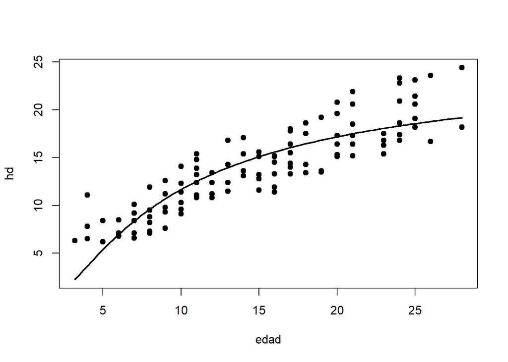

**Figura 2: Modelo Schumacher**

```r
fitPlot(schu)
```

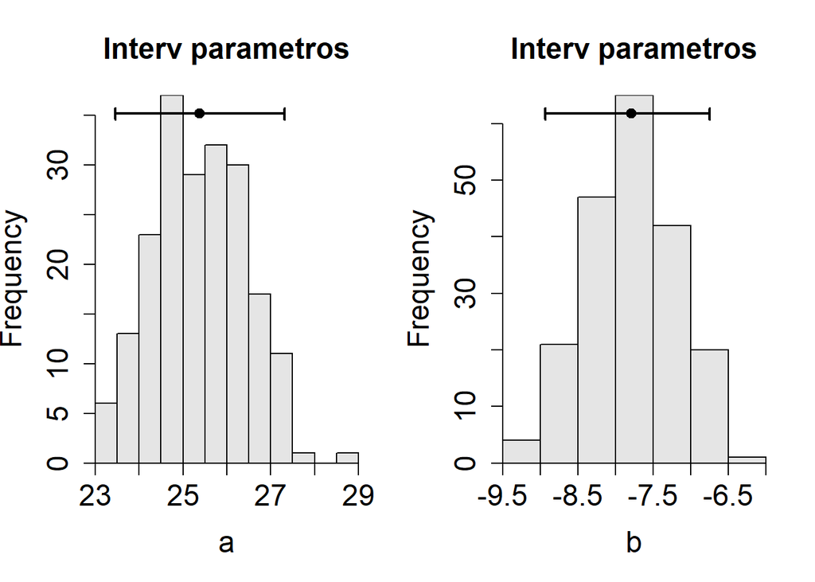

**Figura 3: Distribución de los parametros del modelo**

```
##     95% LCI   95% UCI
## a 23.455746 27.309601
## b -8.936743 -6.747454
```

```r
limp<- nlsBoot(schu, niter = 200)

confint(limp,plot=TRUE,cex.lab=1.5,cex.axis=1.5,cex.main=1.5,main="Interv parametros")
```

```r
htest(limp,"a",0.24,"less")
```

```
##   Ho Value p value
## a     0.24       1
```

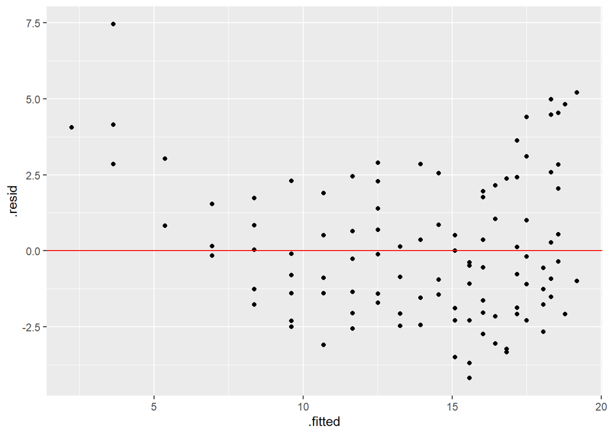

**Figura 4: Residuales del modelo Schumacher**

```r
broom::augment(schu) %>% ggplot(data = ., mapping = aes(x= .fitted, y= .resid)) + geom_point() + geom_abline(slope = 0, color= "red")
```

Si se comparan los modelos de `Schumacher` y `Von Bertalanffy` es posible deducir atreves de sus `deviance` que para $devience(Schumacher)\ > deviance(Von Bertalanffy)$ esto mismo pasa para $AIC$ y este mismo comportamiento con `AIC` y `BIC` lo que sugiere que para los datos el mejor ajuste lo brinda `Von Bertalanffy` (**Tabla 1** y **Tabla 4**).

Se quiere ahora, mirar como se comporta el modelo separado por localidad:

```r
dato1<- datos %>% group_by(loc) %>%  nest()

modelo<- function(data){

  param<- lm(log(hd) ~ I(1/edad), data= data)
  nls(hd ~ a*exp(b*(1/edad)), data = data, start = list(a= exp(coefficients(param)[1]), b= coefficients(param)[2]))
}

dato1<- dato1 %>%
  mutate(model= map(data, modelo))


model2<- dato1 %>%
  mutate(model2= map(model, broom::tidy)) %>%
  unnest(model2, .drop = TRUE)

model2
```

| loc | term | estimate | std.error | statistic | p.value |
| --- | --- | --- | --- | --- | --- |
| PB | a | 24.449109 | 1.0817853 | 22.60070 | 1.698471e-32 |
| PB | b | -8.379745 | 0.6793161 | -12.33556 | 1.102221e-18 |
| CA | a | 28.955600 | 1.3509787 | 21.43305 | 1.862382e-22 |
| CA | b | -7.889187 | 0.6444941 | -12.24090 | 1.411472e-14 |

```r
model3<- dato1 %>%
  mutate(model3= map(model, broom::glance)) %>%
  unnest(model3, .drop = TRUE)

model3
```

| loc | sigma | isConv | finTol | logLik | AIC | BIC | deviance | df.residual |
| --- | --- | --- | --- | --- | --- | --- | --- | --- |
| PB | 1.890621 | TRUE | 2.187791e-06 | -136.72631 | 279.4526 | 286.0667 | 232.3391 | 65 |
| CA | 1.905901 | TRUE | 2.811665e-06 | -79.46528 | 164.9306 | 169.9213 | 134.4009 | 37 |

**Tabla 5: Modelo por localidad Schumacher**

El modelo por localidad ajusta mejor, que sin separarlo, pues al comparar `devience`, `AIC` y `BIC` de los modelos por localidad y sin separar es mas alto el resultado en este ultimo. Tambien si se hace comparaciónes entre los modelos por localidad de `Schumacher` y `Von Bertalanffy` se nota el mismo patron observado en los modelos sin separación, $deviance \hat \ AIC \hat \ BIC(Schumacher) > deviance \hat \ AIC \hat \ BIC(Von Bertalanffy)$, es decir, el modelo `Von Bertalanffy` es el que mejor se ajusta tambien en modelos por localidad. (**Tabla 2** y **Tabla 5**)

## Chapman-Richards

El modelo de la forma $hd= \ \beta_1[1-e^{-\beta_2*edad}]^ {\beta_3}$ se estimó con la ayuda de la literatura, pues es un poco complicado hallar los parámetros, en varios textos la modelación de `altura` y `edad` aparecen valores del orden $A = 83, k = 0.03, p = 4$ por lo cual se intentó a partir de esto hallar parámetros para el modelo.

```r
pr<- lm(log(hd) ~ edad, data = datos)

broom::tidy(pr)
```

| term | estimate | std.error | statistic | p.value |
| --- | --- | --- | --- | --- |
| (Intercept) | 1.89263315 | 0.040319533 | 46.94085 | 8.037463e-72 |
| edad | 0.04615031 | 0.002460689 | 18.75503 | 3.795833e-35 |

```r
exp(log(6.3)/(1.89263315+(0.04615031*3.2)))
```

```
## [1] 2.464752
```

```r
library(nlme)
library(nls2)
library(minpack.lm)
library(robustbase)
library(minpack.lm)

mol<- nlsLM(hd ~ a*(1-exp(-d*edad))^b, data = datos, start = list(a = 30, d = 0.002, b = 0.064))

broom::tidy(mol)
```

| term | estimate | std.error | statistic | p.value |
| --- | --- | --- | --- | --- |
| a | 1.341284e+02 | 1.357087e+03 | 0.09883552 | 0.9214609588 |
| d | 1.972887e-03 | 3.383339e-02 | 0.05831185 | 0.9536132122 |
| b | 6.327532e-01 | 1.628066e-01 | 3.88653346 | 0.0001801383 |

```r
broom::glance(mol)
```

| sigma | isConv | finTol | logLik | AIC | BIC | deviance | df.residual |
| --- | --- | --- | --- | --- | --- | --- | --- |
| 2.09611 | FALSE | 1.490116e-08 | -227.3347 | 462.6693 | 473.3231 | 452.5486 | 103 |

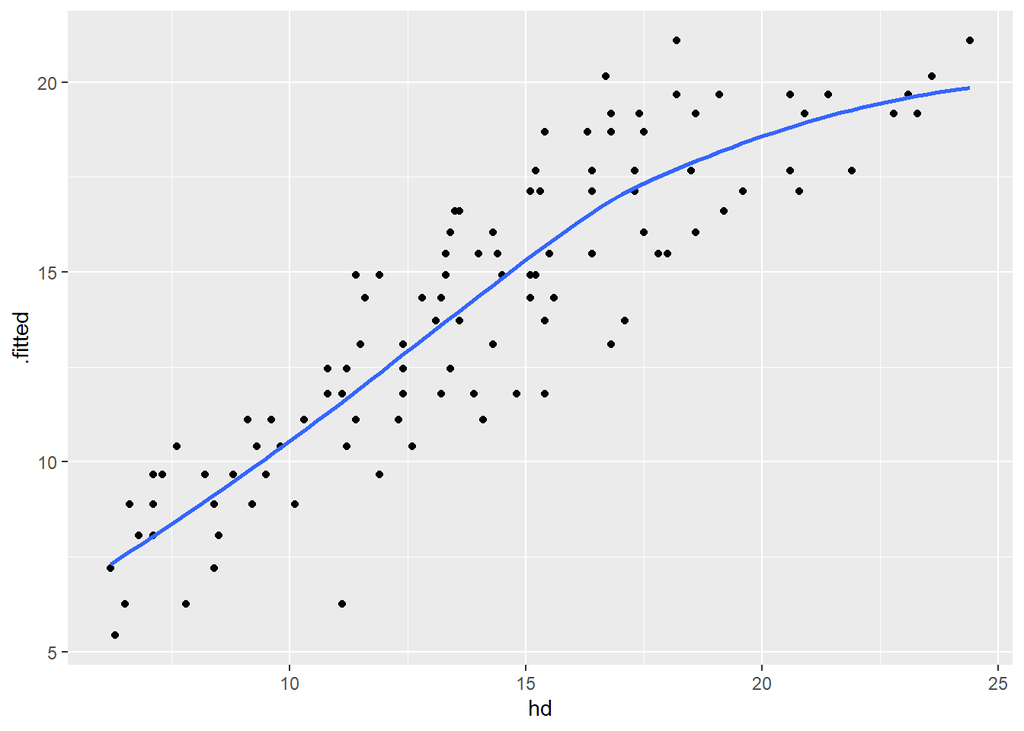

**Figura 5: Modelo Chapman-Richards**

```r
broom::augment(mol) %>% ggplot(data = ., mapping = aes(x= hd, y= .fitted)) +
  geom_point() + geom_smooth(se= FALSE)
```

```r
dato1<- datos %>% group_by(loc) %>%  nest()

modelo<- function(data){
  nlsLM(hd ~ a*(1-exp(-d*edad))^b, data = data, start = list(a = 30, d = 0.002, b = 0.064))
}

dato1<- dato1 %>%
  mutate(model= map(data, modelo))



model2<- dato1 %>%
  mutate(model2= map(model, broom::tidy)) %>%
  unnest(model2, .drop = TRUE)

model2
```

| loc | term | estimate | std.error | statistic | p.value |
| --- | --- | --- | --- | --- | --- |
| PB | a | 1.591608e+02 | 1.990898e+03 | 0.07994425 | 0.9365310559 |
| PB | d | 1.609707e-03 | 3.212816e-02 | 0.05010266 | 0.9601966190 |
| PB | b | 6.654172e-01 | 1.651231e-01 | 4.02982494 | 0.0001508154 |
| CA | a | 1.211714e+02 | 8.673940e+02 | 0.13969596 | 0.8896788538 |
| CA | d | 3.013629e-03 | 3.694464e-02 | 0.08157148 | 0.9354393187 |
| CA | b | 6.442113e-01 | 1.796630e-01 | 3.58566577 | 0.0009901484 |

```r
model3<- dato1 %>%
  mutate(model3= map(model, broom::glance)) %>%
  unnest(model3, .drop = TRUE)

model3
```

| loc | sigma | isConv | finTol | logLik | AIC | BIC | deviance | df.residual |
| --- | --- | --- | --- | --- | --- | --- | --- | --- |
| PB | 1.536393 | FALSE | 1.490116e-08 | -122.30659 | 252.6132 | 261.4320 | 151.07230 | 64 |
| CA | 1.566770 | FALSE | 1.490116e-08 | -71.28941 | 150.5788 | 157.2331 | 88.37168 | 36 |

Al realizar la comparación entre los modelos propuestos por localidades, a partir de los valores obtenidos para el AIC, el BIC y la deviance, se concluye que el modelo que representa un mejor ajuste es el modelo de Von Bertalanffy, puesto que para las localidades es el que registra los menores valores de estos 3 criterios. Luego, al comparar entre el modelo de Schumacher y el modelo de Chapman-Richards se observa que este último arroja menores valores para los 3 criterios mencionados. Por esto se concluye que el modelo de Schumacher fue el modelo que presentó el menor ajuste para los modelos por localidades.